# Analyse von RTR-Daten

Marko Bachl, Universität Hohenheim

# Datensätze

Über GESIS sind die Datensätze aus den TV-Duell-Modulen der GLES verfügbar. Datensätze und Dokumentation zum Duell 2013 zwischen Merkel und Steinbrück können nach Anmeldung hier heruntergeladen werden:

- RTR-Daten Dial: http://dx.doi.org/10.4232/1.11944
- RTR-Daten Push-Button: http://dx.doi.org/10.4232/1.11945
- Befragung: http://dx.doi.org/10.4232/1.12142
- Inhaltsanalyse: http://dx.doi.org/10.4232/1.12770

# Pakete

Falls die folgenden Pakete noch nicht installiert sind, mit `install.packages()` installieren.

```r
library(haven) # Zum Import der SPSS-Datensätze
library(lubridate) # Umgang mit Zeit-Variablen
library(tidyverse); theme_set(theme_bw()) # Datenmanagement und Plots
```

# Dial-Messungen

## Aufbau eines typischen Datensatzes mit Dial-Messungen

Häufig sind RTR-Datensätze in SPSS im sogenannten Wide-Format gespeichert: Jede Zeile ist ein Proband, jede Variable die RTR-Messung in einer Sekunde.

```r
d_dail = read_sav("gles_data/ZA5711_v1-0-0.sav")
d_dail %>% select(match_id, starts_with("t"))
```

| match_id | t000000 | t000001 | t000002 | t000003 | t000004 | t000005 | t000006 | t000007 | t000008 | t000009 | t000010 | t000011 | t000012 | t000013 | t000014 | t000015 | t000016 | t000017 | t000018 | t000019 | t000020 | t000021 | t000022 | t000023 | t000024 | t000025 | t000026 | t000027 | t000028 | … |
| --- | --- | --- | --- | --- | --- | --- | --- | --- | --- | --- | --- | --- | --- | --- | --- | --- | --- | --- | --- | --- | --- | --- | --- | --- | --- | --- | --- | --- | --- | --- |
| LD-A-01 | 4 | 4 | 4 | 4 | 4 | 4 | 4 | 4 | 4 | 4 | 4 | 4 | 4 | 4 | 4 | 4 | 4 | 4 | 4 | 4 | 4 | 4 | 4 | 4 | 4 | 4 | 4 | 4 | 4 | … |
| LD-A-02 | 4 | 4 | 4 | 4 | 4 | 4 | 4 | 4 | 4 | 4 | 4 | 4 | 4 | 4 | 4 | 4 | 4 | 4 | 4 | 4 | 4 | 4 | 4 | 4 | 4 | 4 | 4 | 4 | 4 | … |
| LD-A-03 | 4 | 4 | 4 | 4 | 4 | 4 | 4 | 4 | 4 | 4 | 4 | 4 | 4 | 4 | 4 | 4 | 4 | 4 | 4 | 4 | 4 | 4 | 4 | 4 | 4 | 4 | 4 | 4 | 4 | … |
| LD-A-04 | 4 | 4 | 4 | 4 | 4 | 4 | 4 | 4 | 4 | 4 | 4 | 4 | 4 | 4 | 4 | 4 | 4 | 4 | 4 | 4 | 4 | 4 | 4 | 4 | 4 | 4 | 4 | 4 | 4 | … |
| LD-A-05 | 4 | 4 | 4 | 4 | 4 | 4 | 4 | 4 | 4 | 4 | 4 | 4 | 4 | 4 | 4 | 4 | 4 | 4 | 4 | 4 | 4 | 4 | 4 | 4 | 4 | 4 | 4 | 4 | 4 | … |
| LD-A-06 | 4 | 4 | 4 | 4 | 4 | 4 | 4 | 4 | 4 | 4 | 4 | 4 | 4 | 4 | 4 | 4 | 4 | 4 | 4 | 4 | 4 | 4 | 4 | 4 | 4 | 4 | 4 | 4 | 4 | … |
| LD-A-07 | 4 | 4 | 4 | 4 | 4 | 4 | 4 | 4 | 4 | 4 | 4 | 4 | 4 | 4 | 4 | 4 | 4 | 4 | 4 | 4 | 4 | 4 | 4 | 4 | 4 | 4 | 4 | 4 | 4 | … |
| LD-A-08 | 4 | 4 | 4 | 4 | 4 | 4 | 4 | 4 | 4 | 4 | 4 | 4 | 4 | 4 | 4 | 4 | 4 | 4 | 4 | 4 | 4 | 4 | 4 | 4 | 4 | 4 | 4 | 4 | 4 | … |
| LD-A-09 | 4 | 4 | 4 | 4 | 4 | 4 | 4 | 4 | 4 | 4 | 4 | 4 | 4 | 4 | 4 | 4 | 4 | 4 | 4 | 4 | 4 | 4 | 4 | 4 | 4 | 4 | 4 | 4 | 4 | … |
| LD-A-10 | 4 | 4 | 4 | 4 | 4 | 4 | 4 | 4 | 4 | 4 | 4 | 4 | 4 | 4 | 4 | 4 | 4 | 4 | 4 | 4 | 4 | 4 | 4 | 4 | 4 | 4 | 4 | 4 | 4 | … |

[output cut: 78 more lines]

Für die Datenanalyse in R ist das Long-Format praktischer. Jede Zeile ist eine Kombination von Proband und Messzeitpunkt. Über die Variable *match_id* können Eigenschaften der Probanden zugespielt werden, über den Zeitcode *time* erfolgt die Zuordnung zum Inhalt der Debatte.

```r
d_dail_long = d_dail %>%
  select(match_id, starts_with("t")) %>%
  gather(time, rtr, -match_id) %>%
  mutate(time = str_sub(time, 2),
         time = as.POSIXct(time, format = "%H%M%S"), # Zeit im R Zeitformat
         rtr = rtr - 4) # RTR-Skala von -3 bis 3
```

```
unknown timezone 'default/Europe/Berlin'
```

```r
d_dail_long
```

| match_id | time | rtr |
| --- | --- | --- |
| LD-A-01 | 2018-02-07 00:00:00 | 0 |
| LD-A-02 | 2018-02-07 00:00:00 | 0 |
| LD-A-03 | 2018-02-07 00:00:00 | 0 |
| LD-A-04 | 2018-02-07 00:00:00 | 0 |
| LD-A-05 | 2018-02-07 00:00:00 | 0 |
| LD-A-06 | 2018-02-07 00:00:00 | 0 |
| LD-A-07 | 2018-02-07 00:00:00 | 0 |
| LD-A-08 | 2018-02-07 00:00:00 | 0 |
| LD-A-09 | 2018-02-07 00:00:00 | 0 |
| LD-A-10 | 2018-02-07 00:00:00 | 0 |

[output cut: 990 more lines]

## Plausibilitätscheck der Dial-Daten

Wie häufig hat ein Proband geregelt?

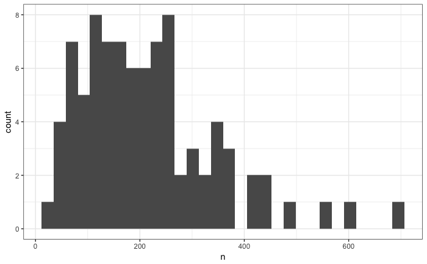

```r
d_dail_long %>% group_by(match_id) %>%
  mutate(change = rtr != lag(rtr)) %>%
  count(change) %>%
  filter(change) %>%
  ggplot(aes(n)) + geom_histogram()
```

```r
d_dail_long %>% group_by(match_id) %>%
  mutate(change = rtr != lag(rtr)) %>%
  count(change) %>%
  filter(change) %>%
  arrange(n) # "LD-A-15"
```

| match_id | change | n |
| --- | --- | --- |
| LD-A-15 | TRUE | 18 |
| LD-A-26 | TRUE | 43 |
| LD-A-29 | TRUE | 44 |
| LD-A-45 | TRUE | 53 |
| LD-A-31 | TRUE | 54 |
| LD-A-17 | TRUE | 61 |
| LD-A-43 | TRUE | 63 |
| LD-A-47 | TRUE | 69 |
| LD-A-11 | TRUE | 76 |
| MZ-J-08 | TRUE | 78 |

[output cut: 78 more lines]

```r
d_dail_long %>% group_by(match_id) %>%
  mutate(change = rtr != lag(rtr)) %>%
  count(change) %>%
  filter(change) %>%
  arrange(desc(n)) # "MZ-J-32", "MZ-J-06", "MZ-J-13", "LD-A-37"
```

| match_id | change | n |
| --- | --- | --- |
| MZ-J-32 | TRUE | 690 |
| MZ-J-06 | TRUE | 610 |
| MZ-J-13 | TRUE | 555 |
| LD-A-37 | TRUE | 493 |
| LD-A-07 | TRUE | 442 |
| MZ-J-17 | TRUE | 438 |
| MZ-J-02 | TRUE | 421 |
| LD-A-38 | TRUE | 407 |
| MZ-J-29 | TRUE | 379 |
| MZ-J-38 | TRUE | 368 |

[output cut: 78 more lines]

Auffällige Probanden

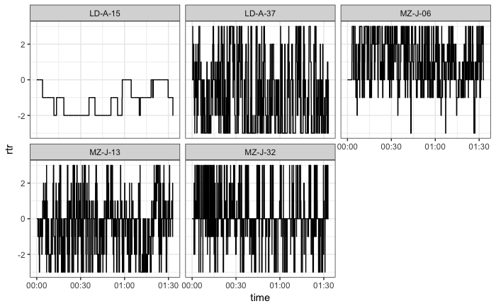

```r
d_dail_long %>%
  filter(match_id %in% c("LD-A-15", "MZ-J-32", "MZ-J-06", "MZ-J-13", "LD-A-37")) %>%
  ggplot(aes(time, rtr)) + geom_line() + facet_wrap("match_id")
```

## Aggregation der RTR-Messungen über Personen

Für die einfachste Variante der typischen RTR-Kurve werden die Messungen aller Personen zu einer Sekunde als Mittelwert zusammengefasst.

```r
d_dail_long %>%
  group_by(time) %>%
  summarise(M_rtr = mean(rtr),
            SD_rtr = sd(rtr),
            n_rtr = n())
```

| time | M_rtr | SD_rtr | n_rtr |
| --- | --- | --- | --- |
| 2018-02-07 00:00:00 | 0.00000000 | 0.0000000 | 88 |
| 2018-02-07 00:00:01 | 0.00000000 | 0.0000000 | 88 |
| 2018-02-07 00:00:02 | 0.00000000 | 0.0000000 | 88 |
| 2018-02-07 00:00:03 | 0.00000000 | 0.0000000 | 88 |
| 2018-02-07 00:00:04 | 0.00000000 | 0.0000000 | 88 |
| 2018-02-07 00:00:05 | 0.00000000 | 0.0000000 | 88 |
| 2018-02-07 00:00:06 | 0.00000000 | 0.0000000 | 88 |
| 2018-02-07 00:00:07 | 0.00000000 | 0.0000000 | 88 |
| 2018-02-07 00:00:08 | 0.00000000 | 0.0000000 | 88 |
| 2018-02-07 00:00:09 | 0.00000000 | 0.0000000 | 88 |

[output cut: 990 more lines]

Ein Liniendiagramm ergibt die typische RTR-Kurve.

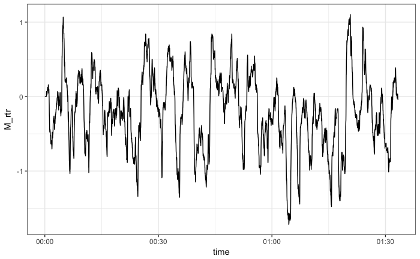

```r
d_dail_long %>%
  group_by(time) %>%
  summarise(M_rtr = mean(rtr),
            SD_rtr = sd(rtr),
            n_rtr = n()) %>%
  ggplot(aes(time, M_rtr)) + geom_line(aes(time, M_rtr))
```

# Push-Button-Messungen

## Aufbau eines Datensatzes mit Push-button-Messungen

**Disclaimer: Ich selbst habe noch nie Push-Button-Daten erhoben oder substantiell analysiert. Die Darstellungen hierzu beruhen lediglich auf meinen Versuchen mit den GLES-Daten und auf Gesprächen mit anderen.**

Push-Button-Messungen werden in der Regel als Event-Daten aufgezeichnet. Dabei wird für jeden Knopf die Aktivitätszeit protokolliert (z.B. Start und Ende des Drückens oder nur Start des Drückens). Vor der Analyse werden diese Daten häufig in einen Datensatz mit regelmäßigen Zeitmessungen transformiert. In den GLES-Daten wird analog zu den Dails für jede Sekunde berichtet, wie häufig ein Proband einen Knopf in dieser Sekunde betätigt hat. Der SPSS-Datensatz ist ebenfalls im Wide-Format gespeichert.

```r
d_pb = read_sav("gles_data/ZA5712_v1-0-0.sav") %>%
  filter(versuchsbedingung == 2) # Nur "normale" Video-Rezeption
d_pb %>% select(match_id, merkel_m_t000059, merkel_p_t000059,
                steinbrueck_m_t000059, steinbrueck_p_t000059) # Beispiel für Sekunde 59
```

| match_id | merkel_m_t000059 | merkel_p_t000059 | steinbrueck_m_t000059 | steinbrueck_p_t000059 |
| --- | --- | --- | --- | --- |
| KO-B-02 | 0 | 0 | 0 | 0 |
| KO-B-04 | 0 | 0 | 0 | 0 |
| KO-B-05 | 0 | 0 | 0 | 0 |
| KO-B-06 | 0 | 0 | 0 | 0 |
| KO-B-07 | 0 | 0 | 0 | 0 |
| KO-B-08 | 0 | 0 | 0 | 0 |
| KO-B-09 | 0 | 0 | 0 | 0 |
| KO-B-10 | 0 | 0 | 0 | 0 |
| KO-B-11 | 0 | 0 | 0 | 0 |
| KO-B-12 | 0 | 0 | 0 | 0 |

[output cut: 69 more lines]

Für unsere Analysen ist wieder das Long-Format praktischer. Beachtet, dass der Datensatz nun im “Very-Long-Format” (in Ermangelung eines besseren Begriffs) ist: Eine Zeile enspricht der Zahl der Aktivitäten eines Probanden in einer Sekunde auf einem Knopf - da es vier Knöpfe gibt, sind das vier Messungen pro Proband und Sekunde.

```r
d_pb_long = d_pb %>%
  select(match_id, contains("_t")) %>%
  gather(tmp, rtr, -match_id) %>%
  separate(tmp, c("cand", "valence", "time")) %>%
  mutate(time = str_sub(time, 2), time = as.POSIXct(time, format = "%H%M%S"),
         valence = factor(valence, labels = c("negative", "positive")))
```

```
attributes are not identical across measure variables;
they will be dropped
```

```r
d_pb_long %>%
  filter(match_id == "KO-C-24") %>%
  arrange(time) # Beispiel für einen Probanden
```

| match_id | cand | valence | time | rtr |
| --- | --- | --- | --- | --- |
| KO-C-24 | merkel | negative | 2018-02-07 00:00:00 | 0 |
| KO-C-24 | merkel | positive | 2018-02-07 00:00:00 | 0 |
| KO-C-24 | steinbrueck | negative | 2018-02-07 00:00:00 | 0 |
| KO-C-24 | steinbrueck | positive | 2018-02-07 00:00:00 | 0 |
| KO-C-24 | merkel | negative | 2018-02-07 00:00:01 | 0 |
| KO-C-24 | merkel | positive | 2018-02-07 00:00:01 | 0 |
| KO-C-24 | steinbrueck | negative | 2018-02-07 00:00:01 | 0 |
| KO-C-24 | steinbrueck | positive | 2018-02-07 00:00:01 | 0 |
| KO-C-24 | merkel | negative | 2018-02-07 00:00:02 | 0 |
| KO-C-24 | merkel | positive | 2018-02-07 00:00:02 | 0 |

[output cut: 990 more lines]

## Plausibilitätscheck der Push-Button-Daten

Wie häufig wird ein Knopf pro Sekunde betätigt?

```r
d_pb_long %>% count(rtr)
```

| rtr | n |
| --- | --- |
| 0 | 1746135 |
| 1 | 14794 |
| 2 | 4611 |
| 3 | 2403 |
| 4 | 808 |
| 5 | 384 |
| 6 | 129 |
| 7 | 16 |
| 8 | 4 |

```r
d_pb_long %>%
  group_by(cand, valence) %>%
  count(rtr) %>%
  unite("cand_valence", c(cand, valence)) %>%
  spread(cand_valence, n) # Ich persönlich halte 2 oder mehr Aktionen pro Sekunde für unplausibel
```

|  | rtr | merkel_negative | merkel_positive | steinbrueck_negative | steinbrueck_positive |
| --- | --- | --- | --- | --- | --- |
| 1 | 0 | 436468 | 436959 | 439352 | 433356 |
| 2 | 1 | 3077 | 3796 | 1947 | 5974 |
| 3 | 2 | 1362 | 934 | 630 | 1685 |
| 4 | 3 | 1033 | 364 | 275 | 731 |
| 5 | 4 | 250 | 146 | 74 | 338 |
| 6 | 5 | 88 | 75 | 29 | 192 |
| 7 | 6 | 41 | 37 | 11 | 40 |
| 8 | 7 | 2 | 6 | 3 | 5 |
| 9 | 8 | NA | 4 | NA | NA |

Wie häufig drücken die Probanden im Zeitverlauf?

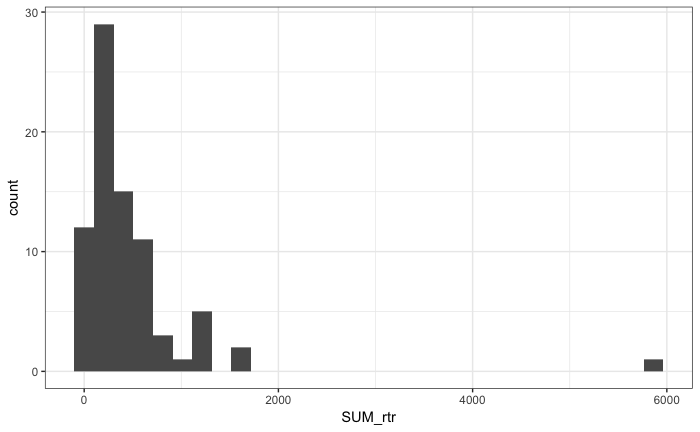

```r
d_pb_long %>% group_by(match_id) %>%
  summarise(SUM_rtr = sum(rtr)) %>%
  ggplot(aes(SUM_rtr)) + geom_histogram()
```

```r
d_pb_long %>% group_by(match_id) %>%
  summarise(SUM_rtr = sum(rtr)) %>%
  arrange(desc(SUM_rtr)) # "KO-C-48" sollte ausgeschlossen werden
```

| match_id | SUM_rtr |
| --- | --- |
| KO-C-48 | 5891 |
| KO-C-21 | 1639 |
| MZ-H-17 | 1592 |
| MZ-H-24 | 1267 |
| MZ-H-22 | 1262 |
| KO-C-34 | 1225 |
| KO-B-12 | 1212 |
| KO-C-39 | 1167 |
| MZ-H-16 | 1031 |
| KO-C-22 | 763 |

[output cut: 69 more lines]

Entscheidung: Umkodieren der RTR-Messungen zu dichotomen Items (Knopf in Sekunde gedrückt); Ausschluss von “KO-C-48”.

```r
d_pb_long = d_pb_long %>%
  filter(match_id != "KO-C-48") %>%
  mutate(rtr = as.numeric(rtr > 0))
d_pb_long %>% group_by(cand, valence) %>%
  count(rtr) %>%
  filter(rtr == 1)
```

| cand | valence | rtr | n |
| --- | --- | --- | --- |
| merkel | negative | 1 | 3935 |
| merkel | positive | 1 | 5281 |
| steinbrueck | negative | 1 | 2576 |
| steinbrueck | positive | 1 | 8397 |

## Aggregation der RTR-Messungen über Personen

Entscheidungen bei der Aggregation der Push-Button-Daten:

- Zusammenfassung von Items?
- Zusammenfassung von Messzeitpunkten?

Ohne weitere Zusammenfassung: Anzahl bzw. Anteil (standardisiert, für Gruppenvergleiche in der App) der Personen, die in einer Sekunde einen Knopf gedrückt haben.

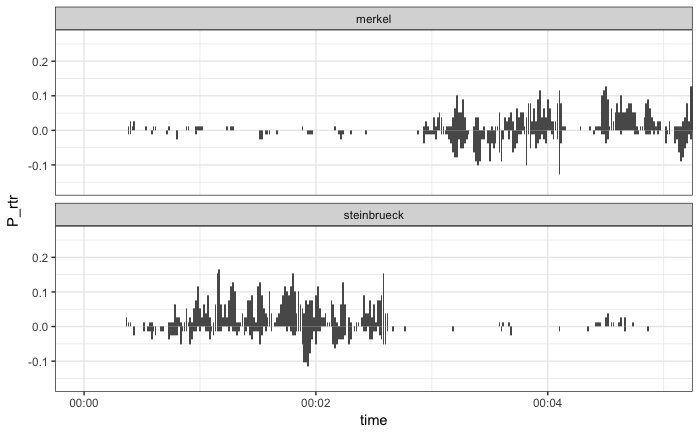

```r
d_pb_long %>% group_by(time, cand, valence) %>%
  summarise(P_rtr = mean(rtr), n_rtr = n()) %>%
  ungroup %>%
  mutate(P_rtr = if_else(valence == "positive", P_rtr, P_rtr * -1)) %>%
  ggplot(aes(time, P_rtr)) + geom_bar(stat = "identity", position = "dodge") +
  facet_wrap("cand", ncol = 1) +
  coord_cartesian(xlim = c(as.POSIXct("00:00:00", format = "%H:%M:%S"),
                           as.POSIXct("00:05:00", format = "%H:%M:%S")))
```

Keine Zusammenfassung der Items, Bewertungen pro Minute.

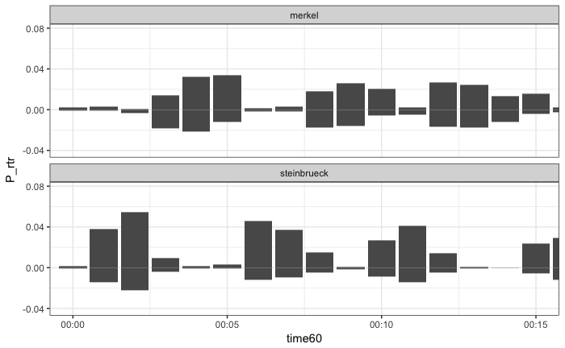

```r
d_pb_long %>% mutate(time60 = round_date(time, unit = "60 secs")) %>%
  group_by(time60, cand, valence) %>%
  summarise(P_rtr = mean(rtr), n_rtr = n()) %>%
  ungroup %>%
  mutate(P_rtr = if_else(valence == "positive", P_rtr, P_rtr * -1)) %>%
  ggplot(aes(time60, P_rtr)) + geom_bar(stat = "identity", position = "dodge") +
  facet_wrap("cand", ncol = 1) +
  coord_cartesian(xlim = c(as.POSIXct("00:00:00", format = "%H:%M:%S"),
                           as.POSIXct("00:15:00", format = "%H:%M:%S")))
```

Within-Kandidaten-Saldo (Kandidat positiv - Kandidat negativ).

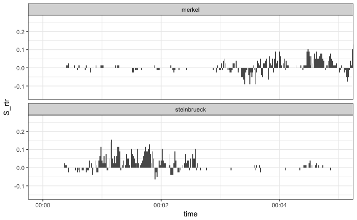

```r
d_pb_long %>% group_by(time, cand, valence) %>%
  summarise(P_rtr = mean(rtr), n_rtr = n()) %>%
  ungroup %>%
  mutate(P_rtr = if_else(valence == "positive", P_rtr, P_rtr * -1)) %>%
  group_by(time, cand) %>%
  summarise(S_rtr = sum(P_rtr)) %>%
  ggplot(aes(time, S_rtr)) + geom_bar(stat = "identity", position = "dodge") +
  facet_wrap("cand", ncol = 1) +
  coord_cartesian(xlim = c(as.POSIXct("00:00:00", format = "%H:%M:%S"),
                           as.POSIXct("00:05:00", format = "%H:%M:%S")))
```

Between-Kandidaten-Saldo (Saldo Merkel - Saldo Steinbrück).

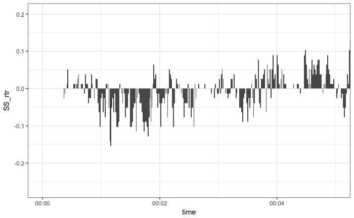

```r
d_pb_long %>% group_by(time, cand, valence) %>%
  summarise(P_rtr = mean(rtr), n_rtr = n()) %>%
  ungroup %>%
  mutate(P_rtr = if_else(valence == "positive", P_rtr, P_rtr * -1)) %>%
  group_by(time, cand) %>%
  summarise(S_rtr = sum(P_rtr)) %>%
  ungroup %>%
  mutate(S_rtr = if_else(cand == "merkel", S_rtr, S_rtr * -1)) %>%
  group_by(time) %>%
  summarise(SS_rtr = sum(S_rtr)) %>%
  ggplot(aes(time, SS_rtr)) + geom_bar(stat = "identity", position = "dodge") +
  coord_cartesian(xlim = c(as.POSIXct("00:00:00", format = "%H:%M:%S"),
                           as.POSIXct("00:05:00", format = "%H:%M:%S")))
```

# Verknüpfung von Datensätzen am Beispiel der Dial-Daten

Probandeneigenschaften können über die *match_id* aus dem Befragungsdatensatz hinzugefügt werden. In diesem einfachen Beispiel wollen wir nach der Kanzlerpräferenz vor der Debatte unterscheiden.

```r
d_survey = read_sav("gles_data/ZA5709_v3-0-0.sav", user_na = TRUE)
d_kpraef = d_survey %>%
  mutate(kpraef = as_factor(a38)) %>%
  select(match_id, kpraef)
d_kpraef
```

| match_id | kpraef |
| --- | --- |
| KO-B-02 | Angela Merkel |
| KO-B-04 | keinen von beiden |
| KO-B-05 | keinen von beiden |
| KO-B-06 | Peer Steinbrueck |
| KO-B-07 | Peer Steinbrueck |
| KO-B-10 | Angela Merkel |
| KO-B-11 | Peer Steinbrueck |
| KO-B-12 | Angela Merkel |
| KO-B-13 | Angela Merkel |
| KO-C-15 | Angela Merkel |

[output cut: 258 more lines]

```r
d_dail_long %>%
  left_join(d_kpraef, by = "match_id")
```

| match_id | time | rtr | kpraef |
| --- | --- | --- | --- |
| LD-A-01 | 2018-02-07 00:00:00 | 0 | Angela Merkel |
| LD-A-02 | 2018-02-07 00:00:00 | 0 | keinen von beiden |
| LD-A-03 | 2018-02-07 00:00:00 | 0 | Peer Steinbrueck |
| LD-A-04 | 2018-02-07 00:00:00 | 0 | keinen von beiden |
| LD-A-05 | 2018-02-07 00:00:00 | 0 | Angela Merkel |
| LD-A-06 | 2018-02-07 00:00:00 | 0 | Angela Merkel |
| LD-A-07 | 2018-02-07 00:00:00 | 0 | Peer Steinbrueck |
| LD-A-08 | 2018-02-07 00:00:00 | 0 | keinen von beiden |
| LD-A-09 | 2018-02-07 00:00:00 | 0 | Peer Steinbrueck |
| LD-A-10 | 2018-02-07 00:00:00 | 0 | Peer Steinbrueck |

[output cut: 990 more lines]

Auf dieser Basis können wir Zeitreihen für die drei Gruppen erstellen und visuell vergleichen.

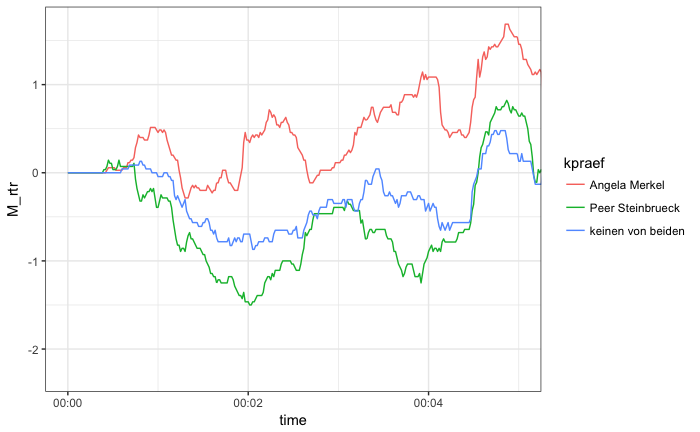

```r
d_dail_long %>%
  left_join(d_kpraef, by = "match_id") %>%
  filter(kpraef != "keine Angabe") %>%
  group_by(time, kpraef) %>%
  summarise(M_rtr = mean(rtr),
            SD_rtr = sd(rtr),
            n_rtr = n()) %>%
    ggplot(aes(time, M_rtr, color = kpraef)) + geom_line(aes(time, M_rtr)) +
  coord_cartesian(xlim = c(as.POSIXct("00:00:00", format = "%H:%M:%S"),
                           as.POSIXct("00:05:00", format = "%H:%M:%S")))
```

Der Inhaltsanalyse-Datensatz enthält in jeder Zeile eine Aussage mit Start- und Endzeit.

```r
d_content = read_sav("gles_data/ZA5710_v2-1-0.sav")
d_content = d_content %>%
  mutate(start_time = paste(v2, v3, v4, sep = ":"),
         end_time = paste(v5, v6, v7, sep = ":"),
         start_time = as.POSIXct(start_time, format = "%H:%M:%S"),
         end_time = as.POSIXct(end_time, format = "%H:%M:%S")) # Zeitmarken im R Zeitformat
d_content %>% select(start_time, end_time, v1, v10, v12)
```

| start_time | end_time | v1 | v10 | v12 |
| --- | --- | --- | --- | --- |
| 2018-02-07 00:00:09 | 2018-02-07 00:00:16 | 1 | 10 | NA |
| 2018-02-07 00:00:16 | 2018-02-07 00:00:22 | 2 | 10 | NA |
| 2018-02-07 00:00:23 | 2018-02-07 00:00:26 | 3 | 10 | NA |
| 2018-02-07 00:00:27 | 2018-02-07 00:00:34 | 4 | 10 | NA |
| 2018-02-07 00:00:35 | 2018-02-07 00:00:42 | 5 | 10 | NA |
| 2018-02-07 00:00:42 | 2018-02-07 00:00:47 | 6 | 2 | 9 |
| 2018-02-07 00:00:47 | 2018-02-07 00:00:47 | 7 | 10 | NA |
| 2018-02-07 00:00:48 | 2018-02-07 00:00:49 | 8 | 2 | 9 |
| 2018-02-07 00:00:50 | 2018-02-07 00:00:53 | 9 | 2 | 2 |
| 2018-02-07 00:00:54 | 2018-02-07 00:01:04 | 10 | 2 | 2 |

[output cut: 867 more lines]

In diesem Format können die Aussagen in Plots eingezeichent werden (z.B. der Sprecher, *v10*).

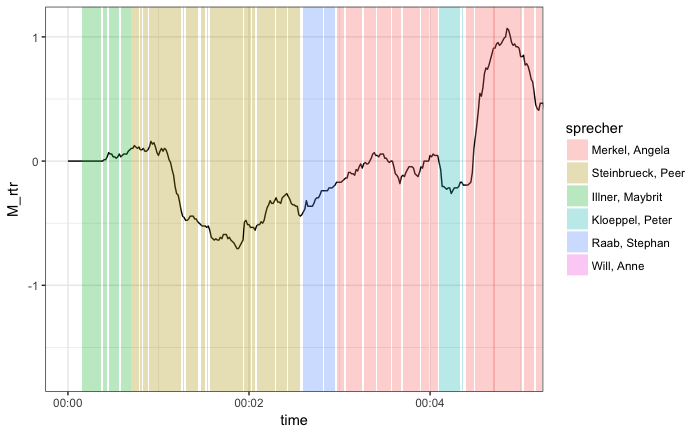

```r
d_sprecher = d_content %>%
  mutate(sprecher = as_factor(v10)) %>%
  select(start_time, end_time, v1, sprecher)
d_dail_long %>%
  group_by(time) %>%
  summarise(M_rtr = mean(rtr),
            SD_rtr = sd(rtr),
            n_rtr = n()) %>%
  ggplot(aes(time, M_rtr)) + geom_line(aes(time, M_rtr)) +
  geom_rect(data = d_sprecher, aes(xmin = start_time, xmax = end_time,
                                   ymin = -Inf, ymax = Inf, fill = sprecher),
            alpha = 0.3, inherit.aes = FALSE) +
  coord_cartesian(xlim = c(as.POSIXct("00:00:00", format = "%H:%M:%S"),
                           as.POSIXct("00:05:00", format = "%H:%M:%S")))
```

Für das Fusionieren des Inhaltsanalyse-Datensatzes mit den RTR-Messungen benötigen wir einen Datensatz, in dem jede Sekunde einer Aussage zugeordnet ist. Diese Zuordnung können wir beispielsweise so erreichen.

```r
d_aus_id = d_content %>%
  select(start_time, end_time, v1)
d_aus_id_long = seq.POSIXt(min(d_dail_long$time), max(d_dail_long$time), by = "sec") %>%
  map_df(~d_aus_id %>% filter(.x >= start_time & .x < end_time) %>% mutate(time = .x)) %>%
  select(time, v1)
d_aus_id_long
```

| time | v1 |
| --- | --- |
| 2018-02-07 00:00:09 | 1 |
| 2018-02-07 00:00:10 | 1 |
| 2018-02-07 00:00:11 | 1 |
| 2018-02-07 00:00:12 | 1 |
| 2018-02-07 00:00:13 | 1 |
| 2018-02-07 00:00:14 | 1 |
| 2018-02-07 00:00:15 | 1 |
| 2018-02-07 00:00:16 | 2 |
| 2018-02-07 00:00:17 | 2 |
| 2018-02-07 00:00:18 | 2 |

[output cut: 990 more lines]

Wir sehen, dass die Aussagen nicht völlig überschneidungsfrei sind. Für manche statistischen Analysezugänge müssten wir diese Doppelungen bereinigen.

```r
d_aus_id_long %>%
  count(time) %>%
  count(n)
```

| n | nn |
| --- | --- |
| 1 | 4926 |
| 2 | 130 |
| 3 | 1 |

Nun können wir z.B. den Sprecher jeder Sekunde im RTR-Datensatz einfügen.

```r
d_dail_long %>%
  left_join(d_aus_id_long, by = "time") %>%
  left_join(d_sprecher %>% select(v1, sprecher), by = "v1")
```

```
Column `v1` has different attributes on LHS and RHS of join
```

| match_id | time | rtr | v1 | sprecher |
| --- | --- | --- | --- | --- |
| LD-A-01 | 2018-02-07 00:00:00 | 0 | NA | NA |
| LD-A-02 | 2018-02-07 00:00:00 | 0 | NA | NA |
| LD-A-03 | 2018-02-07 00:00:00 | 0 | NA | NA |
| LD-A-04 | 2018-02-07 00:00:00 | 0 | NA | NA |
| LD-A-05 | 2018-02-07 00:00:00 | 0 | NA | NA |
| LD-A-06 | 2018-02-07 00:00:00 | 0 | NA | NA |
| LD-A-07 | 2018-02-07 00:00:00 | 0 | NA | NA |
| LD-A-08 | 2018-02-07 00:00:00 | 0 | NA | NA |
| LD-A-09 | 2018-02-07 00:00:00 | 0 | NA | NA |
| LD-A-10 | 2018-02-07 00:00:00 | 0 | NA | NA |

[output cut: 990 more lines]

# Identifikation von auffälligen Aussagen mit RTR-(Dial)-Messungen

Neben der visuellen Inspektion der RTR-Kurve sind zwei Vorgehen verbreitet, um auffällige Aussagen in einer RTR-Kurve zu identifizieren:

- Vergleich mit absoluten Grenzwerten (z.B. +/- 1.5 Skalenpunkte von 0)
- Stärkste Abweichungen vom Mittelwert der RTR-Kurve (z.B. +/- 2 Standardabweichungen vom Mittelwert)

Z.B. Passagen, in denen die Bewertung durch das gesamte Publikum den Grenzwert von +/- 1 Skalenpunkten überschreitet.

```r
peaks = d_dail_long %>%
  group_by(time) %>%
  summarise(M_rtr = mean(rtr)) %>%
  filter(abs(M_rtr) > 1) %>%
  mutate(peak_lag = difftime(time, lag(time), "secs")) %>% ungroup # Nur Peaks
ctr = 1
for (i in 2:nrow(peaks)) {
  if (peaks$peak_lag[i] > 5 | is.na(peaks$peak_lag[i])) ctr[i] = ctr[i - 1] + 1 else ctr[i] = ctr[i - 1]
  } # Zusammenfassung von Peak-Messungen, die innerhalb von 5 Sekunden liegen, zu einem Peak
peaks = peaks %>%
  mutate(peak = ctr) %>%
  group_by(peak) %>%
  summarise(peak_start = min(time),
            peak_end = max(time),
            peak_med = median(time),
            peak_rtr = ifelse(abs(min(M_rtr)) > abs(max(M_rtr)), min(M_rtr), max(M_rtr))) # Peaks
peaks
```

| peak | peak_start | peak_end | peak_med | peak_rtr |
| --- | --- | --- | --- | --- |
| 1 | 2018-02-07 00:04:51 | 2018-02-07 00:04:53 | 2018-02-07 00:04:52 | 1.068182 |
| 2 | 2018-02-07 00:06:37 | 2018-02-07 00:06:39 | 2018-02-07 00:06:38 | -1.034091 |
| 3 | 2018-02-07 00:11:37 | 2018-02-07 00:11:37 | 2018-02-07 00:11:37 | -1.022727 |
| 4 | 2018-02-07 00:24:15 | 2018-02-07 00:24:37 | 2018-02-07 00:24:26 | -1.340909 |
| 5 | 2018-02-07 00:30:55 | 2018-02-07 00:30:59 | 2018-02-07 00:30:57 | -1.090909 |
| 6 | 2018-02-07 00:34:56 | 2018-02-07 00:35:39 | 2018-02-07 00:35:19 | -1.352273 |
| 7 | 2018-02-07 00:39:35 | 2018-02-07 00:39:52 | 2018-02-07 00:39:43 | -1.147727 |
| 8 | 2018-02-07 00:42:19 | 2018-02-07 00:42:48 | 2018-02-07 00:42:33 | -1.215909 |
| 9 | 2018-02-07 00:56:55 | 2018-02-07 00:56:59 | 2018-02-07 00:56:57 | -1.045455 |
| 10 | 2018-02-07 01:03:49 | 2018-02-07 01:04:59 | 2018-02-07 01:04:24 | -1.715909 |

[output cut: 7 more lines]

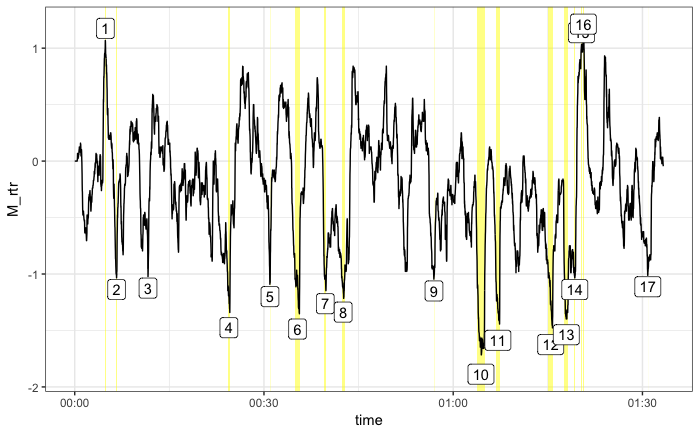

```r
d_dail_long %>%
  group_by(time) %>%
  summarise(M_rtr = mean(rtr)) %>%
  ggplot(aes(time, M_rtr)) +
  geom_rect(data = peaks, aes(xmin = peak_start, xmax = peak_end, ymin = -Inf, ymax = Inf),
            fill = "yellow", alpha = 0.5, inherit.aes = FALSE) +
  geom_line() +
  geom_label(data = peaks, aes(peak_med, peak_rtr + peak_rtr*0.1, label = peak), inherit.aes = FALSE) # Alle Peaks in der Kurve
```

Z.B. Passagen, in denen die Bewertung durch das gesamte Publikum 2 SD vom Mittelwert abweichen.

```r
peaks = d_dail_long %>%
  group_by(time) %>%
  summarise(M_rtr = mean(rtr)) %>%
  ungroup %>%
  mutate(M_M_rtr = mean(M_rtr), SD_M_rtr = sd(M_rtr),
         loli = M_M_rtr - 2 * SD_M_rtr,
         upli = M_M_rtr + 2 * SD_M_rtr) %>%
  filter(M_rtr > upli | M_rtr < loli) %>%
  ungroup %>%
  mutate(peak_lag = difftime(time, lag(time), "secs")) %>% ungroup # Nur Peaks
ctr = 1
for (i in 2:nrow(peaks)) {
  if (peaks$peak_lag[i] > 5 | is.na(peaks$peak_lag[i])) ctr[i] = ctr[i - 1] + 1 else ctr[i] = ctr[i - 1]
  } # Zusammenfassung von Peak-Messungen, die innerhalb von 5 Sekunden liegen, zu einem Peak
peaks = peaks %>%
  mutate(peak = ctr) %>%
  group_by(peak) %>%
  summarise(peak_start = min(time),
            peak_end = max(time),
            peak_med = median(time),
            peak_rtr = ifelse(abs(min(M_rtr)) > abs(max(M_rtr)), min(M_rtr), max(M_rtr))) # Peaks
peaks
```

| peak | peak_start | peak_end | peak_med | peak_rtr |
| --- | --- | --- | --- | --- |
| 1 | 2018-02-07 00:04:40 | 2018-02-07 00:05:02 | 2018-02-07 00:04:51 | 1.0681818 |
| 2 | 2018-02-07 00:24:28 | 2018-02-07 00:24:36 | 2018-02-07 00:24:32 | -1.3409091 |
| 3 | 2018-02-07 00:26:37 | 2018-02-07 00:26:40 | 2018-02-07 00:26:38 | 0.8409091 |
| 4 | 2018-02-07 00:35:26 | 2018-02-07 00:35:37 | 2018-02-07 00:35:31 | -1.3522727 |
| 5 | 2018-02-07 00:42:38 | 2018-02-07 00:42:38 | 2018-02-07 00:42:38 | -1.2159091 |
| 6 | 2018-02-07 00:44:00 | 2018-02-07 00:44:00 | 2018-02-07 00:44:00 | 0.7954545 |
| 7 | 2018-02-07 00:44:06 | 2018-02-07 00:44:24 | 2018-02-07 00:44:14 | 0.8409091 |
| 8 | 2018-02-07 00:49:23 | 2018-02-07 00:49:24 | 2018-02-07 00:49:23 | 0.8409091 |
| 9 | 2018-02-07 01:03:57 | 2018-02-07 01:04:58 | 2018-02-07 01:04:27 | -1.7159091 |
| 10 | 2018-02-07 01:06:52 | 2018-02-07 01:07:22 | 2018-02-07 01:07:09 | -1.4431818 |

[output cut: 5 more lines]

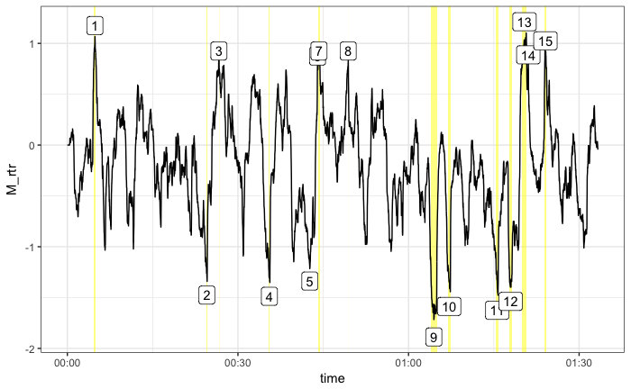

```r
d_dail_long %>%
  group_by(time) %>%
  summarise(M_rtr = mean(rtr)) %>%
  ggplot(aes(time, M_rtr)) +
  geom_rect(data = peaks, aes(xmin = peak_start, xmax = peak_end, ymin = -Inf, ymax = Inf),
            fill = "yellow", alpha = 0.5, inherit.aes = FALSE) +
  geom_line() +
  geom_label(data = peaks, aes(peak_med, peak_rtr + peak_rtr*0.1, label = peak), inherit.aes = FALSE) # Alle Peaks in der Kurve
```

Dieselbe Logik lässt sich auf die Identifikation besonders polarisierender Passagen übertragen. Wir müssen dazu lediglich die Mittelwert-Zeitreihe durch eine Standardabweichung-Zeitreihe ersetzen.

```r
peaks = d_dail_long %>%
  group_by(time) %>%
  summarise(SD_rtr = sd(rtr)) %>%
  filter(abs(SD_rtr) > 1.7) %>%
  mutate(peak_lag = difftime(time, lag(time), "secs")) %>% ungroup # Nur Peaks
ctr = 1
for (i in 2:nrow(peaks)) {
  if (peaks$peak_lag[i] > 5 | is.na(peaks$peak_lag[i])) ctr[i] = ctr[i - 1] + 1 else ctr[i] = ctr[i - 1]
  } # Zusammenfassung von Peak-Messungen, die innerhalb von 5 Sekunden liegen, zu einem Peak
peaks = peaks %>%
  mutate(peak = ctr) %>%
  group_by(peak) %>%
  summarise(peak_start = min(time),
            peak_end = max(time),
            peak_med = median(time),
            peak_rtr = max(SD_rtr)) # Peaks
peaks
```

| peak | peak_start | peak_end | peak_med | peak_rtr |
| --- | --- | --- | --- | --- |
| 1 | 2018-02-07 00:03:54 | 2018-02-07 00:04:06 | 2018-02-07 00:04:01 | 1.741977 |
| 2 | 2018-02-07 00:09:15 | 2018-02-07 00:09:28 | 2018-02-07 00:09:19 | 1.743026 |
| 3 | 2018-02-07 00:10:44 | 2018-02-07 00:10:44 | 2018-02-07 00:10:44 | 1.718385 |
| 4 | 2018-02-07 00:11:25 | 2018-02-07 00:11:28 | 2018-02-07 00:11:26 | 1.715228 |
| 5 | 2018-02-07 00:12:37 | 2018-02-07 00:13:00 | 2018-02-07 00:12:48 | 1.757467 |
| 6 | 2018-02-07 00:18:21 | 2018-02-07 00:18:22 | 2018-02-07 00:18:21 | 1.756165 |
| 7 | 2018-02-07 00:19:49 | 2018-02-07 00:20:40 | 2018-02-07 00:20:14 | 1.936694 |
| 8 | 2018-02-07 00:43:28 | 2018-02-07 00:43:31 | 2018-02-07 00:43:29 | 1.745572 |
| 9 | 2018-02-07 01:13:29 | 2018-02-07 01:13:32 | 2018-02-07 01:13:30 | 1.743026 |

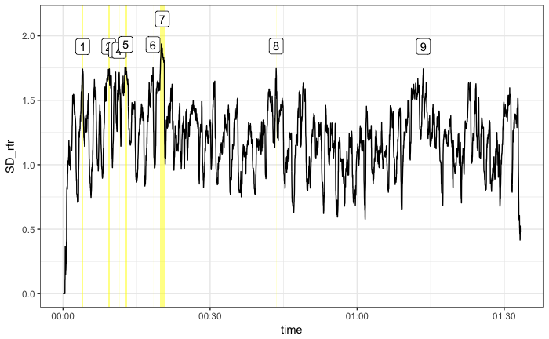

```r
d_dail_long %>%
  group_by(time) %>%
  summarise(SD_rtr = sd(rtr)) %>%
  ggplot(aes(time, SD_rtr)) +
  geom_rect(data = peaks, aes(xmin = peak_start, xmax = peak_end, ymin = -Inf, ymax = Inf),
            fill = "yellow", alpha = 0.5, inherit.aes = FALSE) +
  geom_line() +
  geom_label(data = peaks, aes(peak_med, peak_rtr + peak_rtr*0.1, label = peak), inherit.aes = FALSE) # Alle Peaks in der Kurve
```

# Einfaches Mehrebenen-Modell der RTR-Dail-Daten

## Vorbereitung

Pakete für Mehrebenen-Modelle Falls die folgenden Pakete noch nicht installiert sind, mit `install.packages()` installieren.

```r
library(lme4)
library(sjstats)
```

Daten für kreuzklassifizierte Intercept-Only-Modelle nach Kandidaten

```r
d_ml_merkel = d_dail_long %>%
  left_join(d_aus_id_long, by = "time") %>%
  left_join(d_sprecher %>% select(v1, sprecher), by = "v1") %>%
  filter(sprecher == "Merkel, Angela") %>%
  rename(aus_id = v1) %>%
  mutate(kombi_id = paste0(match_id, aus_id))
```

```
Column `v1` has different attributes on LHS and RHS of join
```

```r
d_ml_merkel
```

| match_id | time | rtr | aus_id | sprecher | kombi_id |
| --- | --- | --- | --- | --- | --- |
| LD-A-01 | 2018-02-07 00:02:58 | 0 | 31 | Merkel, Angela | LD-A-0131 |
| LD-A-02 | 2018-02-07 00:02:58 | 0 | 31 | Merkel, Angela | LD-A-0231 |
| LD-A-03 | 2018-02-07 00:02:58 | 0 | 31 | Merkel, Angela | LD-A-0331 |
| LD-A-04 | 2018-02-07 00:02:58 | -2 | 31 | Merkel, Angela | LD-A-0431 |
| LD-A-05 | 2018-02-07 00:02:58 | 0 | 31 | Merkel, Angela | LD-A-0531 |
| LD-A-06 | 2018-02-07 00:02:58 | 0 | 31 | Merkel, Angela | LD-A-0631 |
| LD-A-07 | 2018-02-07 00:02:58 | 0 | 31 | Merkel, Angela | LD-A-0731 |
| LD-A-08 | 2018-02-07 00:02:58 | 0 | 31 | Merkel, Angela | LD-A-0831 |
| LD-A-09 | 2018-02-07 00:02:58 | 0 | 31 | Merkel, Angela | LD-A-0931 |
| LD-A-10 | 2018-02-07 00:02:58 | 0 | 31 | Merkel, Angela | LD-A-1031 |

[output cut: 990 more lines]

```r
d_ml_steinbrueck = d_dail_long %>%
  left_join(d_aus_id_long, by = "time") %>%
  left_join(d_sprecher %>% select(v1, sprecher), by = "v1") %>%
  filter(sprecher == "Steinbrueck, Peer") %>%
  rename(aus_id = v1) %>%
  mutate(rtr = rtr * -1, # Drehen der Werte für Steinbrück
         kombi_id = paste0(match_id, aus_id))
```

```
Column `v1` has different attributes on LHS and RHS of join
```

```r
d_ml_steinbrueck
```

| match_id | time | rtr | aus_id | sprecher | kombi_id |
| --- | --- | --- | --- | --- | --- |
| LD-A-01 | 2018-02-07 00:00:42 | -1 | 6 | Steinbrueck, Peer | LD-A-016 |
| LD-A-02 | 2018-02-07 00:00:42 | 0 | 6 | Steinbrueck, Peer | LD-A-026 |
| LD-A-03 | 2018-02-07 00:00:42 | 0 | 6 | Steinbrueck, Peer | LD-A-036 |
| LD-A-04 | 2018-02-07 00:00:42 | 0 | 6 | Steinbrueck, Peer | LD-A-046 |
| LD-A-05 | 2018-02-07 00:00:42 | 0 | 6 | Steinbrueck, Peer | LD-A-056 |
| LD-A-06 | 2018-02-07 00:00:42 | 0 | 6 | Steinbrueck, Peer | LD-A-066 |
| LD-A-07 | 2018-02-07 00:00:42 | 0 | 6 | Steinbrueck, Peer | LD-A-076 |
| LD-A-08 | 2018-02-07 00:00:42 | 0 | 6 | Steinbrueck, Peer | LD-A-086 |
| LD-A-09 | 2018-02-07 00:00:42 | 0 | 6 | Steinbrueck, Peer | LD-A-096 |
| LD-A-10 | 2018-02-07 00:00:42 | 0 | 6 | Steinbrueck, Peer | LD-A-106 |

[output cut: 990 more lines]

## Varianzdekomposition

Wir zerlegen die Varianz in vier Komponenten:

- *kombi_id*: Messmodell; hier ein einfacher Mittelwert der RTR-Werte einer Person während einer Aussage; kann durch Interaktionen zwischen Personen- und Inhaltsmerkmalen erklärt werden.
- *match_id*: Varianz der Messmodelle innerhalb der Aussagen zwischen den Personen; kann durch Personenmerkmale erklärt werden.
- *aus_id*: Varianz der Messmodelle innerhalb der Personen zwischen den Aussagen; kann durch Aussagenmerkmale erklärt werden.
- Residualvarianz; Abweichungen der einzelenen Messungen vom Messmodell; hier vom einfachen Mittelwert

Für die Aussagen von Angela Merkel

```r
m0_merkel = d_ml_merkel %>%
  lmer(rtr ~ 1 + (1 | match_id) + (1 | aus_id) + (1 | kombi_id), data = .)
m0_merkel %>% summary
```

```
Linear mixed model fit by REML ['lmerMod']
Formula: rtr ~ 1 + (1 | match_id) + (1 | aus_id) + (1 | kombi_id)
   Data: .

REML criterion at convergence: 251107.7

Scaled residuals:
     Min       1Q   Median       3Q      Max
-10.6386  -0.0348   0.0005   0.0354  12.8207

Random effects:
 Groups   Name        Variance Std.Dev.
 kombi_id (Intercept) 1.115    1.0558
 aus_id   (Intercept) 0.157    0.3963
 match_id (Intercept) 0.535    0.7315
 Residual             0.155    0.3938
Number of obs: 174152, groups:  kombi_id, 21384; aus_id, 243; match_id, 88

Fixed effects:
            Estimate Std. Error t value
(Intercept)  0.06399    0.08234   0.777
```

```r
m0_merkel %>% icc
```

```
Linear mixed model
 Family: gaussian (identity)
Formula: rtr ~ 1 + (1 | match_id) + (1 | aus_id) + (1 | kombi_id)

  ICC (kombi_id): 0.568210
    ICC (aus_id): 0.080046
  ICC (match_id): 0.272716
```

Für die Aussagen von Peer Steinbrück

```r
m0_steinbrueck = d_ml_steinbrueck %>%
  lmer(rtr ~ 1 + (1 | match_id) + (1 | aus_id) + (1 | kombi_id), data = .)
```